# Multivariate Regression and Gradient Boosting

## Summary

In this article, I summerize the ideas behind boosted regression and apply the concept to Locally Weighted Regression with boosting by Random Forest Ensembles and Extreme Gradient Boosting (XGBoost).

```python
import numpy as np
import pandas as pd
from scipy.linalg import lstsq
from scipy.sparse.linalg import lsmr
import matplotlib.pyplot as plt
from scipy.interpolate import interp1d, griddata, LinearNDInterpolator, NearestNDInterpolator
from sklearn.ensemble import RandomForestRegressor
from sklearn.model_selection import KFold, train_test_split as tts
from sklearn.metrics import mean_squared_error as mse
from sklearn.metrics import mean_absolute_error as mae
from sklearn.preprocessing import StandardScaler
from sklearn.tree import DecisionTreeRegressor
from sklearn.linear_model import LinearRegression, Lasso, Ridge, ElasticNet
import matplotlib.pyplot as plt
from matplotlib import pyplot
```

# Locally Weighted Regression

Given a set of observations $X$ with corresponding continuous target $y$, we could assume that the target is a function of a linear combination of the features, with some random noise:

$$ y = X\beta + \sigma \epsilon $$

Here, \beta is are the weights of the linear relationship between $X$ and $y$, $\epsilon$ is a random normal variable, and $sigma$ scales the random noise. Using this assumption, we can attempt transform this equation to make predictions about what $y$ could be based on a real dataset $X$. By mutiplying through with the transpose of $X$, we get

$$ X^Ty = X^TX \beta + X^T\sigma \epsilon $$

Under the assumption $X^TX$ is invertible, we can isolate the weighting vector beta

$$ \beta = (X^TX)^{-1}X^Ty - + (X^TX)^{-1}X^T\sigma \epsilon $$

At this point, we should assume that this model describes the relationship between the features and the data well, and that the error associated with this model is normal and averages out to zero. We will investigate some cases in which this is not true, but for now, we can use this to eliminate the error term for now. We can now make a prediction of what the correct weights of the model should be:

$$ \bar{\beta} = (X^TX)^{-1}X^Ty - + (X^TX)^{-1}X^T\sigma \epsilon $$

Using this, we can finally make predictions with the model

$$ \hat{y} = X(X^TX)^{-1}X^Ty $$

Here, $\hat{y}$ are the predictions of the model for a given dataset $X$.

At this point, we can re-investigate the assumption that the relationship between the features and the targets are in fact, linear. In general, this may not be the case. However, we can try to assume that there is some local linearity - that the relationship appears linear within some small range of a particular target or observation. We can define locality as Euclidean locality. For two vectors $\vec{v}$ and $\vec{w}$, we can define distance $d$ as the following:

$$ d_{(\vec{v},\vec{w})} = \sqrt{(v_1 - w_1)^2 + (v_2 - w_2)^2 +...+(v_n - w_n)^2} $$

This assumes $n$ observations in $X$. Using this we can calculate the distance between two observation vectors in $X$ and define some threshold for locality. In doing so, we can create a distance dependent weighting matrix $W_k$ for some $k$th observation. $W$ is a diagonal matrix of side length $n$, meaning only the diagonal elements ($W_{11}$, etc) are non-zero. The remaining elements of W will somehow help define locality. We can mulitply this matrix through our inital model to get

$$ W_ky = W_kX\beta + W_k\sigma \epsilon $$

We can again solve for beta and yhat. However, this time, we get

$$ \bar{\beta} = (X^TW_kX)^{-1}X^TW_ky $$

and

$$ \hat{y} = X(X^TW_kX)^{-1}X^TW_ky $$

An example of the code used to build a Locally Weighted Regression Function is shown below:

```python
def lw_reg(X, y, xnew, kern, tau, intercept):
    n = len(X)
    yest = np.zeros(n)

    if len(y.shape)==1: # here we make column vectors
      y = y.reshape(-1,1)

    if len(X.shape)==1:
      X = X.reshape(-1,1)

    if intercept:
      X1 = np.column_stack([np.ones((len(X),1)),X])
    else:
      X1 = X

    w = np.array([kern((X - X[i])/(2*tau)) for i in range(n)]) # here we compute n vectors of weights

    #Looping through all X-points
    for i in range(n):
        W = np.diag(w[:,i])
        b = np.transpose(X1).dot(W).dot(y)
        A = np.transpose(X1).dot(W).dot(X1)
        beta, res, rnk, s = lstsq(A, b)
        yest[i] = np.dot(X1[i],beta)
    if X.shape[1]==1:
      f = interp1d(X.flatten(),yest,fill_value='extrapolate')
    else:
      f = LinearNDInterpolator(X, yest)
    output = f(xnew)
    if sum(np.isnan(output))>0:
      g = NearestNDInterpolator(X,y.ravel())
      output[np.isnan(output)] = g(xnew[np.isnan(output)])
    return output
```

An example of some code used to create a Tricubic function is given below:

```python
# Tricubic Kernel
def Tricubic(x):
  if len(x.shape) == 1:
    x = x.reshape(-1,1)
  d = np.sqrt(np.sum(x**2,axis=1))
  return np.where(d>1,0,70/81*(1-d**3)**3)
```

Here, d is the distance between the nth vector and some other observation vector in the data set. Note that as observations get "farther" way, this drops off quickly, becoming 0 if $d > 1$. Tricubic is not the only possible kerneling function. Two others, Quartic and Epanechnikov, are also given below:

```python
# Quartic Kernel
def Quartic(x):
  if len(x.shape) == 1:
    x = x.reshape(-1,1)
  d = np.sqrt(np.sum(x**2,axis=1))
  return np.where(d>1,0,15/16*(1-d**2)**2)

# Epanechnikov Kernel
def Epanechnikov(x):
  if len(x.shape) == 1:
    x = x.reshape(-1,1)
  d = np.sqrt(np.sum(x**2,axis=1))
  return np.where(d>1,0,3/4*(1-d**2))
```

Below is a comparison of the previously mentioned kerneling functions. Not that they all go to 0 as $d$ goes to 1:

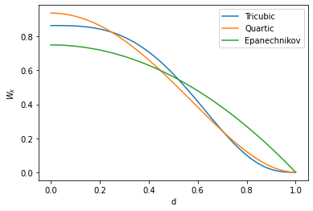

```python
x = np.linspace(0, 1, 100)
plt.figure()
plt.plot(x, Tricubic(x), label = 'Tricubic')
plt.plot(x, Quartic(x), label = 'Quartic')
plt.plot(x, Epanechnikov(x), label = 'Epanechnikov')
plt.xlabel('d')
plt.ylabel(r'$W_k$')
plt.legend()
plt.show()
```

We can control this threshold better with the hyperparamter $\tau$, which scales the range of locality.

## Gradient Boosting

In reality, even assuming local linearity in the place of total linearity may not work as well as we like. However, it's possible that even a poor model can determine something about the broader trends of the model. Assuming we have multiple models that each account for some part of the total relation ship, we can add models together to attempt to replicate the functional relationship. This new model, called an ensemble model, will likely work better than any single one of the original models.

We can define a weak prediction model $F$ that will produce some prediction $F(x_i)$ for some observation $x_i$. The error associated with this prediction is $y_i - F(x_i)$ for some corresponding target value $y_i$. We can define a boosting model, $h$, that will attempt to bridge this gap. $h$ learns on the residuals instead of learning on the targets. As a result, the two models can add together, $F + h$, to accout for different dependencies in the model and provide a much better result.

An example of Locally Weighted Regression boosted by a Random Forest Ensemble is shown below:

```python
def boosted_lwr_rf(X, y, xnew, kern, tau, intercept):
  Fx = lw_reg(X,y,X,kern,tau,intercept)
  new_y = y - Fx
  model = RandomForestRegressor(n_estimators=100,max_depth=2)
  model.fit(X,new_y)
  output = model.predict(xnew) + lw_reg(X,y,xnew,kern,tau,intercept)
  return output
```

## Extreme Gradient Boosting

Extreme Gradient Boosting, or XGBoost, is very similar to Gradient Boost, with an added regularization feature to help protect against overfitting. Begining a a research project in the Distributed Machine Learning Community, XGBoost was popularized for it's use in the winning submission of the Higgs Boson Machine Learning Challenge in 2014.

An advantage of boostings is that you can describe unknown non-linear correlations as the sum of multiple functional relationships. However, implicit in this problem is that it is difficult to tell where non-linearities end and true random noise begins. One of the looming potential dangers of boosting is that in chosing some non-linear function to boost with, such as a Random Forest Regressor or a Neural Network, the boosting function will overstep beyond true relationships and begin to overfit. To limit this, in generating the boosting trees, every split in the XGBoost trees are optimized through a regularized Gain loss function:

$$ Gain = \frac{G_L^2}{H_L+\lambda} + \frac{G_R^2}{H_R+\lambda} + \frac{(G_R +G_L)^2}{H_R + H_L+\lambda} - \gamma $$

Here, $G_L$ are the sum of the residuals in the left child node, and $H_L$ are the number residuals in the left child node (and R for right). $\lambda$ and $\gamma$ are regularization parameters that limit the maxima that the Gain can reach. Normally, Gain is used to identify points at which a split would produce a more accurate model - the higher the gain, the better the split. Choosing hyperparamters such as a high $\gamma$ or $\lambda$ will artificially push the gain down, either through scaling ($\lambda$) or biasing ($\gamma$). In doing so, this limits tree growth and regularizes the model.

```python
def boosted_lwr_xgb(X, y, xnew, kern, tau, intercept):
  Fx = lw_reg(X,y,X,kern,tau,intercept)
  new_y = y - Fx
  model = xgb.XGBRegressor(objective ='reg:squarederror',n_estimators=100,reg_lambda=1,alpha=1,gamma=1,max_depth=10)
  model.fit(X,new_y)
  output = model.predict(xnew) + lw_reg(X,y,xnew,kern,tau,intercept)
  return output
```

## Methods

```python
cars = pd.read_csv('cars.csv')
carsx = cars[['ENG','CYL','WGT']].values
carsy = cars['MPG'].values
```

```python
boston = pd.read_csv('Boston Housing Prices.csv')
bostonx = boston[['crime', 'nox', 'rooms', 'highway', 'tax']].values
bostony = boston['cmedv'].values
```

```python
def validate(X, y):
  kf = KFold(n_splits=30,shuffle=True,random_state=1234)
  scale = StandardScaler()
  mse_lwr = []
  mse_blwr = []
  mse_xgb = []
  mae_lwr = []
  mae_blwr = []
  mae_xgb = []
  for idxtrain, idxtest in kf.split(X):
    xtrain = X[idxtrain]
    ytrain = y[idxtrain]
    ytest = y[idxtest]
    xtest = X[idxtest]
    xtrain = scale.fit_transform(xtrain)
    xtest = scale.transform(xtest)
    yhat_lwr = lw_reg(xtrain,ytrain, xtest,Tricubic,tau=1.2,intercept=True)
    yhat_blwr = boosted_lwr_rf(xtrain,ytrain, xtest,Tricubic,tau=1.2,intercept=True)
    yhat_xgb = boosted_lwr_rf(xtrain,ytrain, xtest,Tricubic,tau=1.2,intercept=True)
    mse_lwr.append(mse(ytest,yhat_lwr))
    mse_blwr.append(mse(ytest,yhat_blwr))
    mse_xgb.append(mse(ytest,yhat_xgb))
    mae_lwr.append(mae(ytest,yhat_lwr))
    mae_blwr.append(mae(ytest,yhat_blwr))
    mae_xgb.append(mae(ytest,yhat_xgb))
  print('The Cross-validated Mean Squared Error for LWR is : '+str(np.mean(mse_lwr)))
  print('The Cross-validated Mean Squared Error for RFBLWR is : '+str(np.mean(mse_blwr)))
  print('The Cross-validated Mean Squared Error for XGBLWR is : '+str(np.mean(mse_xgb)))
  print()
  print('The Cross-validated Mean Absolute Error for LWR is : '+str(np.mean(mae_lwr)))
  print('The Cross-validated Mean Absolute Error for RFBLWR is : '+str(np.mean(mae_blwr)))
  print('The Cross-validated Mean Absolute Error for XGBLWR is : '+str(np.mean(mae_xgb)))
```

## Results and Conclusions

The results of the previously run tests are shown below:

```python
print('Cars Data Results:')
validate(carsx, carsy)
print()
print()
print('Boston Housing Data Results:')
validate(bostonx, bostony)
```

```
Cars Data Results:
The Cross-validated Mean Squared Error for LWR is : 17.033084693285247
The Cross-validated Mean Squared Error for RFBLWR is : 16.771846227376738
The Cross-validated Mean Squared Error for XGBLWR is : 16.6779217893921

The Cross-validated Mean Absolute Error for LWR is : 3.0139395686588366
The Cross-validated Mean Absolute Error for RFBLWR is : 2.997523584778987
The Cross-validated Mean Absolute Error for XGBLWR is : 2.988280781427709


Boston Housing Data Results:
The Cross-validated Mean Squared Error for LWR is : 22.895490066411597
The Cross-validated Mean Squared Error for RFBLWR is : 21.363388396702817
The Cross-validated Mean Squared Error for XGBLWR is : 21.456250780966887

The Cross-validated Mean Absolute Error for LWR is : 3.1677071974576516
The Cross-validated Mean Absolute Error for RFBLWR is : 3.0335389496217853
The Cross-validated Mean Absolute Error for XGBLWR is : 3.0357540620819616
```

Future work can analyze optimization of the boosting function, as well as different types of boosting functions, such as polynomial regressors and Neural Networks.